# 13. JSON and Iteration

Today, we are going to run through a number of different examples of creating data sets through API calls. For the most part, these will make queries that return JSON data and require some form of iteration to process them. I will show you two in the notes and two others in the notebook.

If you have no prior programming experience, this may be a bit overwhelming, but that’s okay. I will make sure you have all of the API interface code you actually need for Project 4 already outlined for you.

## Wikipedia Page Views

We will start with defining a base URL using the protocol, authority, path, and query parameters.

```r
url_base <- modify_url(
  "https://en.wikipedia.org/w/api.php",
  query = list(action = "query", format = "json", prop = "pageviews")
)
```

To fetch a particular page, we need add an additional parameter called titles that contains the page title you want to grab. We can then return and parse the HTTP response as JSON.

```r
url_str <- modify_url(url_base, query = list(titles = "ChatGPT"))
res <- dsst_cache_get(url_str, cache_dir = "cache", force = FALSE)
obj <- content(res, type = "application/json")
```

The shape of `obj` is fairly complex. We could walk through it using the names function, dollar sign, and bracket operator. In RStudio, you can look at the object easily by clicking on it in the Environment Panel. With some experimentation, you can see that the core of the data we want is nested here:

```r
pviews <- obj$query$pages[[1]]$pageviews
pviews
```

```
## $`2023-01-24`
## [1] 246519
##
## $`2023-01-25`
## [1] 238953
##
## $`2023-01-26`
## [1] 240126
##
## $`2023-01-27`
## [1] 239290
##
## $`2023-01-28`
## [1] 215210
##
## $`2023-01-29`
## [1] 220959
##
## $`2023-01-30`
## [1] 283857
##
## $`2023-01-31`
## [1] 278906
##
## $`2023-02-01`
## [1] 257708
##
## $`2023-02-02`
## [1] 267112
##
## $`2023-02-03`
## [1] 264945
##
## $`2023-02-04`
## [1] 211780
##
## $`2023-02-05`
## [1] 209862
##
## $`2023-02-06`
```

[output cut: 124 more lines]

```
##
## $`2023-03-20`
## [1] 301553
##
## $`2023-03-21`
## [1] 283419
##
## $`2023-03-22`
## [1] 284092
##
## $`2023-03-23`
## [1] 280056
##
## $`2023-03-24`
## NULL
```

We can turn this into a rectangular data set by using the functions found in the slides.

```r
dt <- tibble(
  page = "apple",
  date = ymd(names(pviews)),
  views = map_int(pviews, ~ dsst_null_to_na(..1))
)
dt
```

```
## # A tibble: 60 × 3
##    page  date        views
##    <chr> <date>      <int>
##  1 apple 2023-01-24 246519
##  2 apple 2023-01-25 238953
##  3 apple 2023-01-26 240126
##  4 apple 2023-01-27 239290
##  5 apple 2023-01-28 215210
##  6 apple 2023-01-29 220959
##  7 apple 2023-01-30 283857
##  8 apple 2023-01-31 278906
##  9 apple 2023-02-01 257708
## 10 apple 2023-02-02 267112
## # … with 50 more rows
```

We can then plot the data and see if there are any interesting patterns:

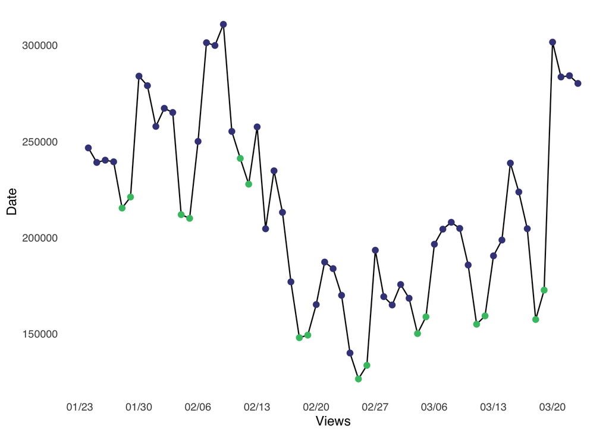

```r
dt %>%
  filter(!is.na(views)) %>%
  mutate(wt = if_else(wday(date, week_start = 1) > 5, "weekend", "weekday")) %>%
  ggplot(aes(date, views)) +
    geom_line() +
    geom_point(aes(color = wt), size = 2, show.legend = FALSE) +
    scale_x_date(
      date_breaks = "1 week",
      date_labels = "%m/%d",
      date_minor_breaks = "1 week"
    ) +
    scale_color_viridis_d(begin = 0.2, end = 0.7) +
    labs(x = "Views", y = "Date") +
    dsst_tufte()
```

### XKCD

As a second task for the notes, let’s create a data set from the API for the popular web comic XKCD. The API has a slightly different structure because the information about the kind of data we want to grab is stored in the path rather than the query parameters. To get the URL for the 10th comic from XKCD, for example, we need this code:

```r
i <- 10
url_str <- modify_url(sprintf("https://xkcd.com/%d/info.0.json", i))
```

In the following code, create a data set for the first 25 webcomes that has the year, month, day, safe title, and transcript of the comics. Notice that I am using some new code to store the data more easily within each loop.

```r
n <- 25
output <- vector("list", length = n)

for (i in seq_len(n))
{
  url_str <- modify_url(sprintf("https://xkcd.com/%d/info.0.json", i))

  res <- dsst_cache_get(url_str, cache_dir = "cache")

  obj <- content(res, type = "application/json")
  output[[i]] <- tibble(
    year = obj$year,
    month = obj$month,
    day = obj$day,
    safe_title = obj$safe_title,
    transcript = obj$transcript
  )
}

output <- bind_rows(output)
output
```

```
## # A tibble: 25 × 5
##    year  month day   safe_title                                      trans…¹
##    <chr> <chr> <chr> <chr>                                           <chr>
##  1 2006  1     1     Barrel - Part 1                                 "[[A b…
##  2 2006  1     1     Petit Trees (sketch)                            "[[Two…
##  3 2006  1     1     Island (sketch)                                 "[[A s…
##  4 2006  1     1     Landscape (sketch)                              "[[A s…
##  5 2006  1     1     Blown apart                                     "[[A b…
##  6 2006  1     1     Irony                                           "Narra…
##  7 2006  1     1     Girl sleeping (Sketch -- 11th grade Spanish cl… "[[Gir…
##  8 2006  1     1     Red spiders                                     "[[Man…
##  9 2006  1     1     Serenity is coming out tomorrow                 "[[Sev…
## 10 2006  1     1     Pi Equals                                       "Pi = …
## # … with 15 more rows, and abbreviated variable name ¹transcript
```

Note that it should be trivial to adjust your code to get all of the comics as long as you know the number of the most recent comic. We are stopping at 25 to reduce our load on their servers and also to avoid a long run.